# Udacity - Ford GoBike System Data

## by Fahad Abudjeen

> This data set includes information about individual rides made in a bike-sharing system covering the greater San Francisco Bay area,  
> Bay Wheels is a regional public bicycle sharing system in California's San Francisco Bay Area. It is operated by Motivate in a partnership with the Metropolitan Transportation Commission and the Bay Area Air Quality Management District.Bay Wheels is the first regional and large-scale bicycle sharing system deployed in California and on the West Coast of the United States. It was established as Bay Area Bike Share in August 2013. As of January 2018, the Bay Wheels system had over 2,600 bicycles in 262 stations across San Francisco, East Bay and San Joseز

## Preliminary Wrangling

```python
# import all packages and set plots to be embedded inline
import numpy as np
import pandas as pd
import matplotlib.pyplot as plt
import seaborn as sb
import datetime as dt

%matplotlib inline
```

## Gathering Data

```python
Ford_GoBike = pd.read_csv("201902-fordgobike-tripdata.csv")
```

```python
Ford_GoBike.head(3)
```

|  | duration_sec | start_time | end_time | start_station_id | start_station_name | start_station_latitude | start_station_longitude | end_station_id | end_station_name | end_station_latitude | end_station_longitude | bike_id | user_type | member_birth_year | member_gender | bike_share_for_all_trip |
| --- | --- | --- | --- | --- | --- | --- | --- | --- | --- | --- | --- | --- | --- | --- | --- | --- |
| 0 | 52185 | 2019-02-28 17:32:10.1450 | 2019-03-01 08:01:55.9750 | 21.0 | Montgomery St BART Station (Market St at 2nd St) | 37.789625 | -122.400811 | 13.0 | Commercial St at Montgomery St | 37.794231 | -122.402923 | 4902 | Customer | 1984.0 | Male | No |
| 1 | 42521 | 2019-02-28 18:53:21.7890 | 2019-03-01 06:42:03.0560 | 23.0 | The Embarcadero at Steuart St | 37.791464 | -122.391034 | 81.0 | Berry St at 4th St | 37.775880 | -122.393170 | 2535 | Customer | NaN | NaN | No |
| 2 | 61854 | 2019-02-28 12:13:13.2180 | 2019-03-01 05:24:08.1460 | 86.0 | Market St at Dolores St | 37.769305 | -122.426826 | 3.0 | Powell St BART Station (Market St at 4th St) | 37.786375 | -122.404904 | 5905 | Customer | 1972.0 | Male | No |

## Assessing Data

### What is the structure of your dataset?

There are **183412** observations in the dataset with **16** variables.

The **16** features and their short description is as follows:

- **duration_sec:** the period duration time by second.
- **start_time:** beginning duration for start time.
- **end_time:** finish duration for end time.
- **start_station_id:** the id number of start station.
- **start_station_name:** the name of kick station.
- **start_station_latitude:** it's location (latitude) of start station.
- **start_station_longitude:** it's location (longitude) of start station
- **end_station_id:** the id number of end station
- **end_station_name:** the name of end station
- **end_station_latitude:** it's location (latitude) of start station
- **end_station_longitude:** it's location (longitude) of start station
- **bike_id:** the number id of bike
- **user_type:** the user type of the bike.
- **member_birth_year:** the birth year of member who use the bike.
- **member_gender:** the member gender who use the bike.
- **bike_share_for_all_trip:** annual membership for qualifying Bay Area residents.

### What is/are the main feature(s) of interest in your dataset?

**Duration** and **location** for use a **bike** is a focus here. Apart from that, I will also take a look at how other variables affect Duration and location for use a bike.

### What features in the dataset do you think will help support your investigation into your feature(s) of interest?

I'm looking forward to exploring features like **start and end station**, **user type**, **member birth year**, **bike share for all trip**, **Member gender** and how they affect Duration and location for use a bike.

```python
# Get the information about dataframe
Ford_GoBike.info()
```

```
<class 'pandas.core.frame.DataFrame'>
RangeIndex: 183412 entries, 0 to 183411
Data columns (total 16 columns):
 #   Column                   Non-Null Count   Dtype
---  ------                   --------------   -----
 0   duration_sec             183412 non-null  int64
 1   start_time               183412 non-null  object
 2   end_time                 183412 non-null  object
 3   start_station_id         183215 non-null  float64
 4   start_station_name       183215 non-null  object
 5   start_station_latitude   183412 non-null  float64
 6   start_station_longitude  183412 non-null  float64
 7   end_station_id           183215 non-null  float64
 8   end_station_name         183215 non-null  object
 9   end_station_latitude     183412 non-null  float64
 10  end_station_longitude    183412 non-null  float64
 11  bike_id                  183412 non-null  int64
 12  user_type                183412 non-null  object
 13  member_birth_year        175147 non-null  float64
 14  member_gender            175147 non-null  object
 15  bike_share_for_all_trip  183412 non-null  object
dtypes: float64(7), int64(2), object(7)
memory usage: 22.4+ MB
```

```python
# show the number of null.
Ford_GoBike.isnull().sum()
```

```
duration_sec                  0
start_time                    0
end_time                      0
start_station_id            197
start_station_name          197
start_station_latitude        0
start_station_longitude       0
end_station_id              197
end_station_name            197
end_station_latitude          0
end_station_longitude         0
bike_id                       0
user_type                     0
member_birth_year          8265
member_gender              8265
bike_share_for_all_trip       0
dtype: int64
```

```python
# get the number of duplicated
Ford_GoBike.duplicated().sum()
```

```
0
```

```python
# show how many famels and male we have:
Ford_GoBike.member_gender.value_counts()
```

```
Male      130651
Female     40844
Other       3652
Name: member_gender, dtype: int64
```

```python
# show the number of user type"
Ford_GoBike.user_type.value_counts()
```

```
Subscriber    163544
Customer       19868
Name: user_type, dtype: int64
```

```python
# show the number of who share for all trip:
Ford_GoBike.bike_share_for_all_trip.value_counts()
```

```
No     166053
Yes     17359
Name: bike_share_for_all_trip, dtype: int64
```

## Cleaning Data

```python
# make a copy of the dataframe
FordGoBike = Ford_GoBike.copy()
```

```python
# Cleaning 1: Change data type start/end time to tto_datetime type.
FordGoBike['start_time'] = pd.to_datetime(FordGoBike['start_time'])
FordGoBike['end_time'] = pd.to_datetime(FordGoBike['end_time'])
```

```python
# Cleaning 2: Change data type for Id to the string type.
FordGoBike['start_station_id'] = FordGoBike['start_station_id'].astype('str')
FordGoBike['end_station_id'] = FordGoBike['end_station_id'].astype('str')
FordGoBike['bike_id'] = FordGoBike['bike_id'].astype('str')
```

```python
# Cleaning 3: convert data type for user type & member gendder to the category type.
FordGoBike['user_type'] = FordGoBike['user_type'].astype('category')
FordGoBike['member_gender'] = FordGoBike['member_gender'].astype('category')
```

```python
#get information about columns and data types:
FordGoBike.info()
```

```
<class 'pandas.core.frame.DataFrame'>
RangeIndex: 183412 entries, 0 to 183411
Data columns (total 16 columns):
 #   Column                   Non-Null Count   Dtype
---  ------                   --------------   -----
 0   duration_sec             183412 non-null  int64
 1   start_time               183412 non-null  datetime64[ns]
 2   end_time                 183412 non-null  datetime64[ns]
 3   start_station_id         183412 non-null  object
 4   start_station_name       183215 non-null  object
 5   start_station_latitude   183412 non-null  float64
 6   start_station_longitude  183412 non-null  float64
 7   end_station_id           183412 non-null  object
 8   end_station_name         183215 non-null  object
 9   end_station_latitude     183412 non-null  float64
 10  end_station_longitude    183412 non-null  float64
 11  bike_id                  183412 non-null  object
 12  user_type                183412 non-null  category
 13  member_birth_year        175147 non-null  float64
 14  member_gender            175147 non-null  category
 15  bike_share_for_all_trip  183412 non-null  object
dtypes: category(2), datetime64[ns](2), float64(5), int64(1), object(6)
memory usage: 19.9+ MB
```

```python
# Cleaning 4: create new column for trip duration in minutes.
FordGoBike['duration_min'] = FordGoBike['duration_sec']/60
```

```python
# Cleaning 5: create new column for end_time only(Date).
FordGoBike['start_date'] = FordGoBike.start_time.dt.strftime('%Y-%m-%d')
```

```python
# Cleaning 6: create new columnn for start_hour_of_day - start_day_of_week - start_month  .
FordGoBike['start_hour_of_day'] = FordGoBike.start_time.dt.strftime('%H')
FordGoBike['start_day_of_week'] = FordGoBike.start_time.dt.strftime('%A')
FordGoBike['start_month'] = FordGoBike.start_time.dt.strftime('%B')
```

```python
# Cleaning 7: create new column for end date .
FordGoBike['end_date'] = FordGoBike.start_time.dt.strftime('%Y-%m-%d')
```

```python
# Cleaning 8: create new columnn for end_hour_of_day - end_day_of_week - end_month  .
FordGoBike['end_hour_of_day'] = FordGoBike.end_time.dt.strftime('%H')
FordGoBike['end_day_of_week'] = FordGoBike.end_time.dt.strftime('%A')
FordGoBike['end_month'] = FordGoBike.end_time.dt.strftime('%B')
```

```python
# Cleaning 9: make a new column for calculating age from "member_birth_year" column.
FordGoBike['member_age'] = 2019 - FordGoBike['member_birth_year']
```

```python
# Cleaning 10: drop nan value from member age column.
FordGoBike['member_age'].dropna(inplace = True)
```

```python
# Cleaning 11: Change data type for member_age to the int type.
FordGoBike['member_age'] = FordGoBike['member_age'].astype('int')
```

## Univariate Exploration

> In this section, investigate distributions of individual variables. If you see unusual points or outliers, take a deeper look to clean things up and prepare yourself to look at relationships between variables.

## 1. What Is the Day Has The Most Trips?

```python
plt.figure(figsize=[15, 10])
base_color = sb.color_palette()[0]
```

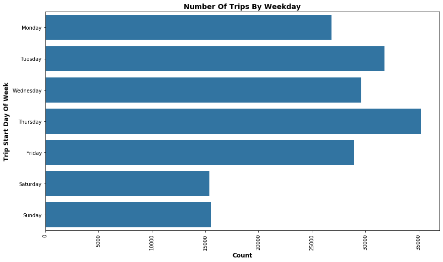

```python
plt.figure(figsize=[14, 8])

weekday = ['Monday', 'Tuesday', 'Wednesday', 'Thursday', 'Friday', 'Saturday', 'Sunday']
weekdaycat = pd.api.types.CategoricalDtype(ordered=True, categories=weekday)
FordGoBike['start_day_of_week'] = FordGoBike['start_day_of_week'].astype(weekdaycat)

sb.countplot(data=FordGoBike, y='start_day_of_week', color=base_color);

plt.title('Number of Trips by weekday'.title(),fontsize = 14, weight = "bold")
plt.xlabel('Count'.title(),fontsize = 12, weight = "bold");
plt.ylabel('Trip Start Day of Week'.title(),fontsize = 12, weight = "bold");
plt.xticks(rotation = 90);
```

This graph show what is the weekdays has the most trips. and it appears the most trips was on **Thursday** and **Tuesday**. and the lowest days was on **Saturday** and **Sunday**.

## 2. what is the Most Majority User Type?

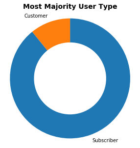

```python
plt.figure(figsize=[10, 5])

sorted_counts = FordGoBike['user_type'].value_counts()

plt.pie(sorted_counts, labels = sorted_counts.index, startangle = 90,
        counterclock = False, wedgeprops = {'width' : 0.4});
plt.axis('square')
plt.title('Most Majority User Type'.title(),fontsize = 14, weight = "bold")
```

This graph show what is the most majority user type and this show represent the majority is to **Subscribers**.

## 3. What Is the Duration Of Most Of The Trips In Minutes?

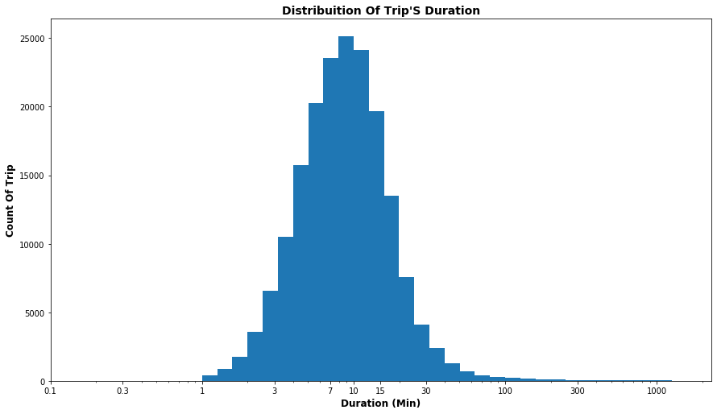

```python
plt.figure(figsize=[14, 8])

plt.figure(figsize=[14.70, 8.27])
bins = 10 ** np.arange(0,3.15+0.1,0.1)
ticks = [0.1,0.3,1,3,7,10,15,30,100,300,1000]
labels = ['{}'.format(v) for v in ticks]

plt.hist(data = FordGoBike, x = 'duration_min', bins = bins);
plt.xscale('log')
plt.xticks(ticks, labels);

plt.title("Distribuition of trip's duration".title(),
               fontsize = 14, weight = "bold")
# Add x label and format it
plt.xlabel('Duration (min)'.title(),
               fontsize = 12, weight = "bold")
# Add y label and format it
plt.ylabel('Count of trip'.title(),
               fontsize = 12, weight = "bold")
```

This chart shows that the most of trips has a duration in range of 5 to 20 minutes and it's unimodal graph.

## Bivariate Exploration

Performing a Bivariate Exploration for some relationship between are the features and find some anwsers to our questions.

## 4. What is the average trips over weekdays in Minutes?

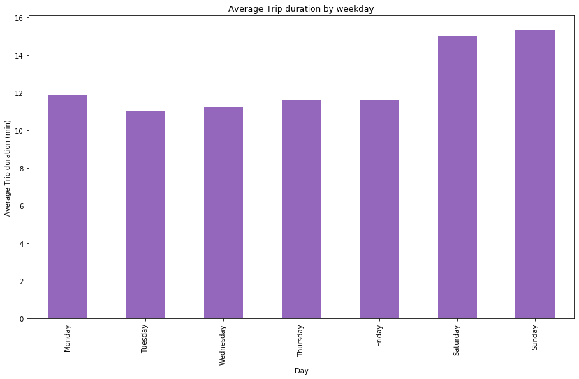

```python
plt.figure(figsize=[14, 8])

base_color = sb.color_palette()[4]
FordGoBike.groupby('start_day_of_week')['duration_min'].mean().plot(kind = "bar", color = base_color);

plt.title("Average Trip duration by weekday")
plt.xlabel('Day')
plt.ylabel('Average Trio duration (min)')
```

This chart shows that the average trips start on Monday to Friday lowest trips duration compared to weekends While On Saturday and Sunday the high duration time.

```python
#Average of trips duration by weekday
print(FordGoBike.groupby('start_day_of_week')['duration_min'].mean())
```

```
start_day_of_week
Monday       11.885994
Tuesday      11.055093
Wednesday    11.227853
Thursday     11.650683
Friday       11.596585
Saturday     15.044367
Sunday       15.329101
Name: duration_min, dtype: float64
```

**Violin plots Visualization**

```python
#As the duration time of Trips are widely, I will choose to do these two subcut in the data frams.
DurationSub100 = FordGoBike.loc[FordGoBike['duration_min'] <= 100]
DurationSub45 = FordGoBike.loc[FordGoBike['duration_min'] <= 45]
```

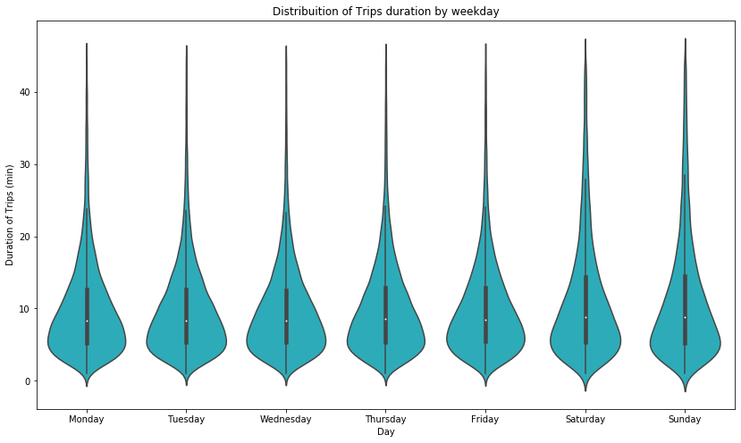

```python
plt.figure(figsize=[14, 8])

base_color = sb.color_palette()[9]

sb.violinplot(data = DurationSub45, x = 'start_day_of_week', y = 'duration_min',
              color = base_color);
plt.title("Distribuition of Trips duration by weekday")
plt.xlabel('Day')
plt.ylabel('Duration of Trips (min)')
```

**Box Plot Visualization**

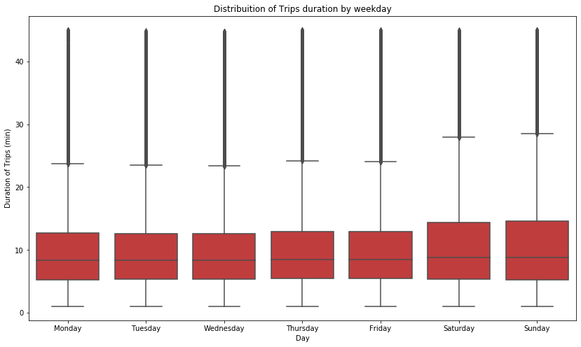

```python
plt.figure(figsize=[14, 8])
base_color = sb.color_palette()[3]

sb.boxplot(data = DurationSub45, x = 'start_day_of_week', y = 'duration_min',
              color = base_color);
plt.title("Distribuition of Trips duration by weekday")
plt.xlabel('Day')
plt.ylabel('Duration of Trips (min)')
```

## 5. Reference to previous question if the User Type is Customer or Subscriber?

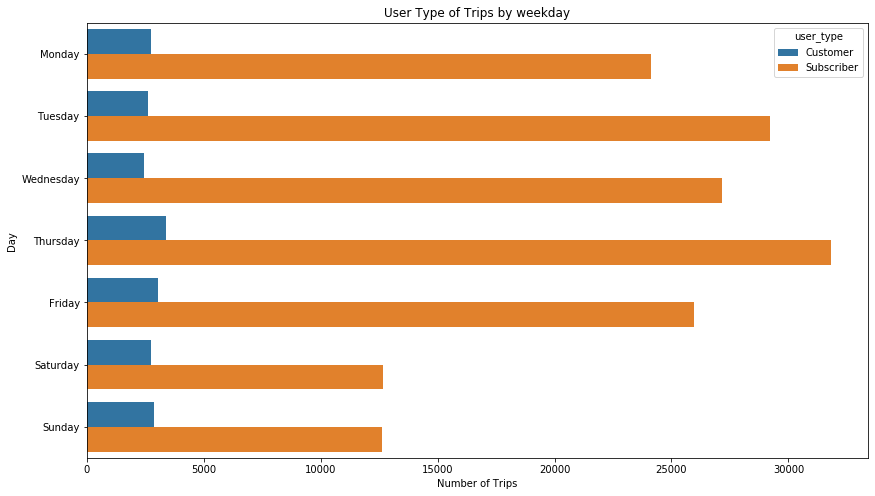

```python
plt.figure(figsize=[14, 8])
sb.countplot(data = FordGoBike, y='start_day_of_week', hue = 'user_type');
plt.title("User Type of Trips by weekday")
plt.xlabel('Number of Trips')
plt.ylabel('Day')
```

This chart shows that the user type most type to sybsciribers and the lowest to customer depends on the average duration.

## 6.What is the most peak time for trips?

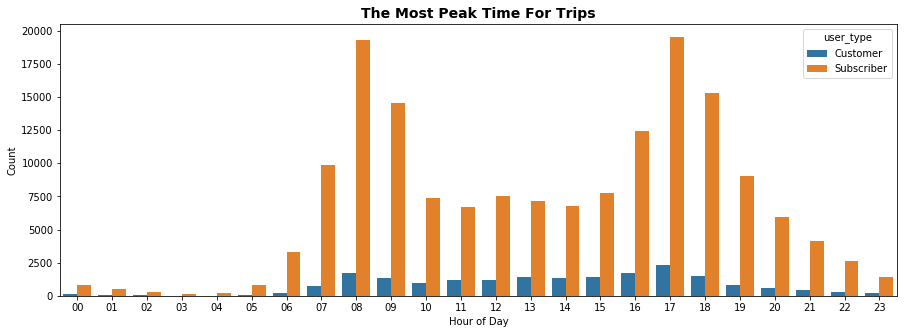

```python
plt.figure(figsize=[15, 5])
sb.countplot(data=FordGoBike, x='start_hour_of_day', hue='user_type');
plt.xlabel('Hour of Day');
plt.ylabel('Count');
plt.title('The most peak time for trips'.title(),fontsize = 14, weight = "bold")
```

This chart shows that the most peak times on two different time start from **07:00 to 10:00** and the second peak time **16:00 to 18:00.**

## 7.Which User Type takes long Duration for Trips?

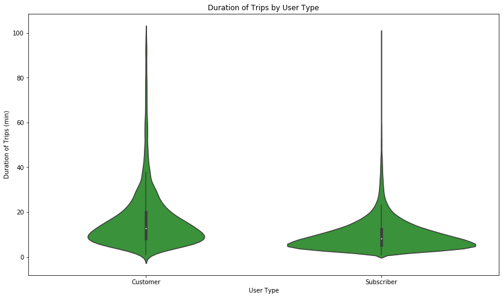

```python
plt.figure(figsize=[14, 8])

base_color = sb.color_palette()[2]
sb.violinplot(data = DurationSub100, x = 'user_type', y = 'duration_min',
              color = base_color)

plt.title("Duration of Trips by User Type")
plt.xlabel('User Type')
plt.ylabel('Duration of Trips (min)')
```

This chart shows that subscribers and costumers have a significantly difference in trips duration.

### Talk about some of the relationships you observed in this part of the investigation. Were there features that strengthened each other in terms of looking at your feature(s) of interest?

> The trips pattern different between subscribers and customers While we seen the subscribers higher than customers as user type. thus most trips ware on workdays from Monday to Friday and show during peak time start from 07:00 to 10:00 and the second peak time 16:00 to 18:00.

### Were there any interesting or surprising interactions between features?

> the interesting the to see ages that higher than 60 and the median. they did trips in peak times!!

## 8. The average trip duration on weekdays between customers and subscribers?

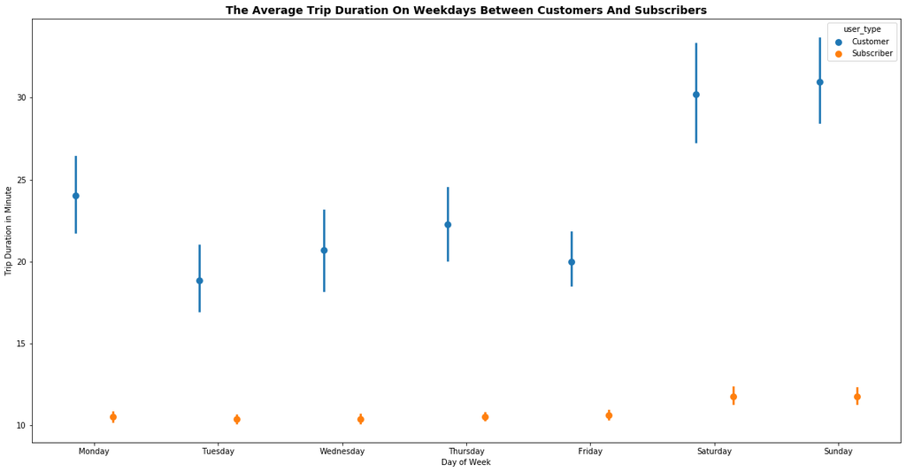

```python
plt.figure(figsize=[20, 10])
sb.pointplot(data=FordGoBike, x='start_day_of_week', y='duration_min', hue='user_type', dodge=0.3, linestyles="");
plt.xlabel('Day of Week');
plt.ylabel('Trip Duration in Minute');
plt.title('The average trip duration on weekdays between customers and subscribers'.title(),fontsize = 14, weight = "bold")
```

This chart show that the subscribers trips shorter than customers on weekdays. both user type have an obvious increased in trip duraction on Saturday and Sunday over weekends

## 9. How does affect the hours days usage with member age for customers and subscribers?

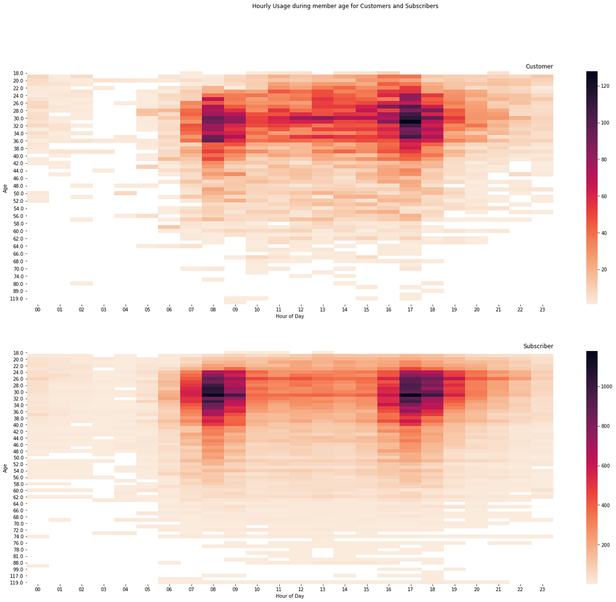

```python
plt.figure(figsize=[25, 20])

plt.suptitle('Hourly Usage during member age for Customers and Subscribers')

plt.subplot(2, 1, 1)
customers = FordGoBike.query('user_type == "Customer"')
ct_counts = customers.groupby(['member_age', 'start_hour_of_day']).size()
ct_counts = ct_counts.reset_index(name='count')
ct_counts = ct_counts.pivot(index='member_age', columns='start_hour_of_day', values='count')
sb.heatmap(ct_counts, cmap='rocket_r');
plt.title('Customer', loc='right');
plt.xlabel('Hour of Day');
plt.ylabel('Age');

plt.subplot(2, 1, 2)
subscribers = FordGoBike.query('user_type == "Subscriber"')
st_counts = subscribers.groupby(['member_age', 'start_hour_of_day']).size()
st_counts = st_counts.reset_index(name='count')
st_counts = st_counts.pivot(index='member_age', columns='start_hour_of_day', values='count')
sb.heatmap(st_counts, cmap='rocket_r');
plt.title('Subscriber', loc='right');
plt.xlabel('Hour of Day');
plt.ylabel('Age');
```